# Correlation and Regression

Nicholas Jacob

11/22/2020

# Regression Homework Helper

I am again going to try to keep it simple by using base R but doing some of the homework questions.

1. Use a scatterplot and the linear correlation coefficient r to determine whether there is a correlation between the two variables. (Note: Use software, and don’t forget to look at the scatterplot!)

First I’ll load the data. I could load the data via a csv but to keep the reprodicibility high, I am going to manually enter the data.

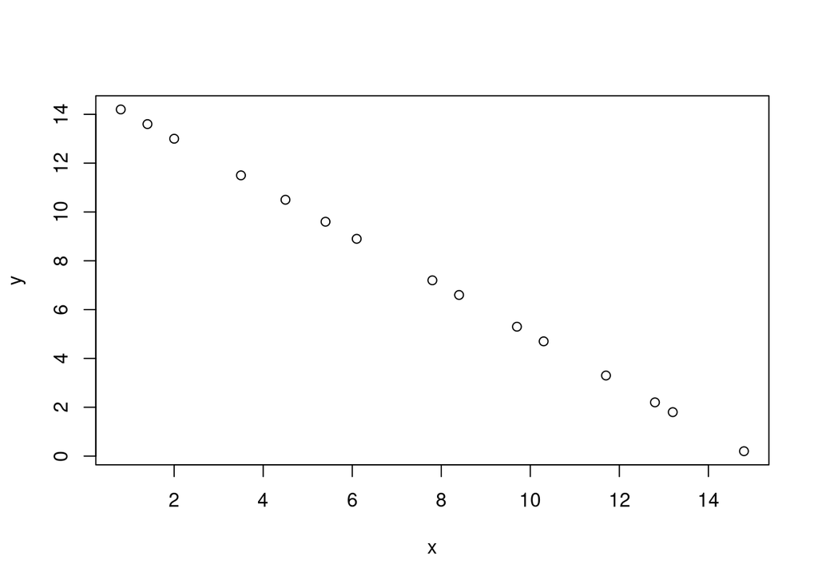

```r
x <-c(0.8,1.4 ,2,3.5,4.5,5.4,6.1,7.8,8.4,9.7,10.3,11.7,12.8,13.2,14.8)
y <- c(14.2,13.6,13,11.5,10.5,9.6,8.9,7.2,6.6,5.3,4.7,3.3,2.2,1.8,0.2)
plot(x,y)
```

That looks rather nicely linear! Of course it is negatively correlated (the slope is negative!).

To get the correlation $r$

```r
cor(x,y,method = "pearson")
```

```
## [1] -1
```

We are using the ‘Pearson’ correlation method here. If I call the **cor** fucntion without that it will give me several answers.

```r
cor.test(x,y)
```

```
##
##  Pearson's product-moment correlation
##
## data:  x and y
## t = -Inf, df = 13, p-value < 2.2e-16
## alternative hypothesis: true correlation is not equal to 0
## 95 percent confidence interval:
##  -1 -1
## sample estimates:
## cor
##  -1
```

Let’s repeat this using the definition of correlation!
$$r = \frac{\sum_{i=1}^n(x_i-\overline x)(y_i-\overline y )}{(n-1)s_xs_y}$$

```r
sx = sd(x)
sy = sd(y)
n = length(x)
xbar = mean(x)
ybar = mean(y)
numerator = mean((x-xbar)*(y-ybar))*n
r = numerator/((n-1)*sx*sy)
r
```

```
## [1] -1
```

Sweet! There are a couple of interesting things I did above! I took a sequence $x$ and subtracted a single value $\overline x$ from each value. I also multiplied sequences.

Let’s also get the equation of the linear relationship.

```r
lm(y~x)
```

```
##
## Call:
## lm(formula = y ~ x)
##
## Coefficients:
## (Intercept)            x
##          15           -1
```

This brings in a couple of interesting R calls. I needed to do a function so I did **y~x** you see that I am making a function! Let’s define a function too so I can make some predictions.

```r
fit = lm(y~x)
slope = coef(fit)[2]
intercept = coef(fit)[1]
yhat <- function(xpredict){
  return( slope*xpredict+intercept)
}
yhat(10)
```

```
## x
## 5
```

So here I did it with a user defined function. While I was doing this I noticed the following command I could have used!

```r
xToPredict <-data.frame(x = c(10))
predict(fit, newdata = xToPredict)
```

```
## 1
## 5
```

We may want commands like this later! This command was a little bit of a pain becuase you can only pass a dataframe to the newdata option. One really nice feature though is that I can do confidence intervals!

```r
predict(fit, newdata = xToPredict, interval = 'confidence')
```

```
##   fit lwr upr
## 1   5   5   5
```

Lastly we shoud perfom a hypothesis test. Here the null hypothesis is that there is no correlation.
$$H_0: \rho =0\\
H_A: \rho\neq 0$$
We have already computed our estimate of the test statistic $r$. Then $t$ is
$$t =
\frac{r\sqrt{n-2}}{\sqrt{1-r^2}}$$
Here the degrees of freedom will be $df=n-2$

```r
t = r*sqrt(n-2)/sqrt(1-r^2)
t
```

```
## [1] -Inf
```

There is no chance this happens! Really I am dividing by 0…

```r
pt(t,n-2)
```

```
## [1] 0
```

So yes, we can reject the null hypothesis, the $p$ is low.

If instead we want to test the slope of the line. We consider the following as the theorectical fit
$$\hat y = \beta_0+\beta_1x$$

The standard error for the slope is
$$SE_{\beta_1} = \sqrt{\frac{MSE}{\sum\left(x_i-\overline x\right)^2}}$$

Where
$$MSE = \frac{\sum_{i=1}^n\left(y_i-\hat y_i\right)^2}{n-2}$$

$MSE$ is referred to as the mean square error. It adds all the square errors and divides by the adjusted total $(n-2)$ because of the degrees of freedom!

```r
yframe = data.frame('Values' = y)
yhat <- predict(fit,yframe)
MSE = sum((y-yhat)^2)/(n-2)
MSE
```

```
## [1] 6.627806e-30
```

The denominator in the $SE$ computation above is sometimes called the $S_{xx}$ The sum of the squares of $x$.

```r
sxx = sum((x-xbar)^2)
```

Then we can now compute the standard error for the slope as

```r
SEslope = sqrt(MSE/sxx)
SEslope
```

```
## [1] 1.514884e-16
```

If instead I wanted to look at the intercept, $\beta_0$, it’s standard error is
$$SE_{\beta_0} = \sqrt{MSE\left(\frac1n+\frac{\overline x}{S_{xx}}\right)}$$

This will be straight forward as I have already computed all these values.

```r
SEintercept = sqrt(MSE*(1/n+xbar^2/sxx))
SEintercept
```

```
## [1] 1.315456e-15
```

Both $\beta_0$ and $\beta_1$ are $t$-student distributed with degrees of freedom $df = n-2$.

If I want to do the confidence interval for a prediction by hand, it is very similar! For an $x_h$ that you want to predict,
$$SE_{x_h}=\sqrt{MSE\left(\frac1n+\frac{\left(x_h-\overline x\right)^2}{S_{xx}}\right)}$$
Again this is $t$-studnet distributed. I won’t do this computation since I had R do it, but I could!

My example is clunky here because I had a perfect fit to begin with but you can see that these computations are not terrible with R! Also we are going to see shortly that R will return all of these values if I ask it to…

```r
summary(fit)
```

```
##
## Call:
## lm(formula = y ~ x)
##
## Residuals:
##        Min         1Q     Median         3Q        Max
## -8.777e-15 -5.387e-16  6.692e-16  1.111e-15  3.821e-15
##
## Coefficients:
##               Estimate Std. Error    t value Pr(>|t|)
## (Intercept)  1.500e+01  1.469e-15  1.021e+16   <2e-16 ***
## x           -1.000e+00  1.692e-16 -5.910e+15   <2e-16 ***
## ---
## Signif. codes:  0 '***' 0.001 '**' 0.01 '*' 0.05 '.' 0.1 ' ' 1
##
## Residual standard error: 2.876e-15 on 13 degrees of freedom
## Multiple R-squared:      1,  Adjusted R-squared:      1
## F-statistic: 3.493e+31 on 1 and 13 DF,  p-value: < 2.2e-16
```

I was thinking about this problem a few hours later and low and behold there is a way to get R to tell you all of these values… Passing the **fit** to the **summary()** function, we see all these outputs computed for you. Standard Errors and even the MSE are computed right here!

Okay I cannot resist graphing…

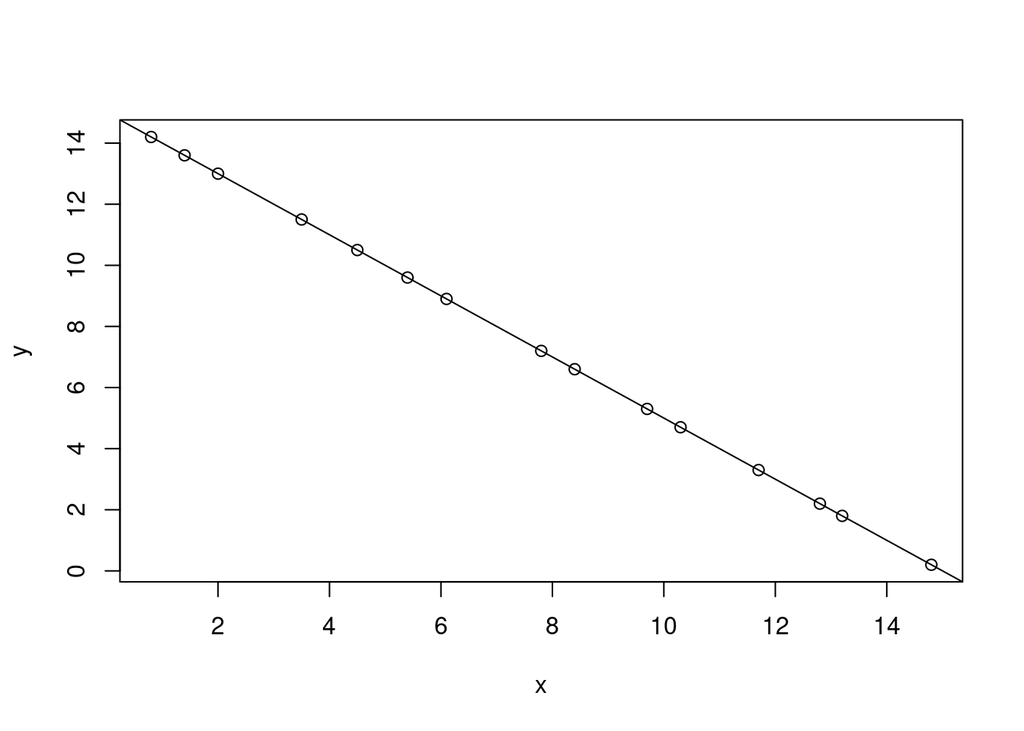

```r
plot(x,y)
abline(fit)
```

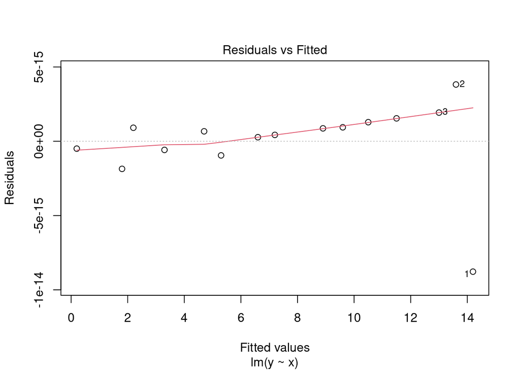

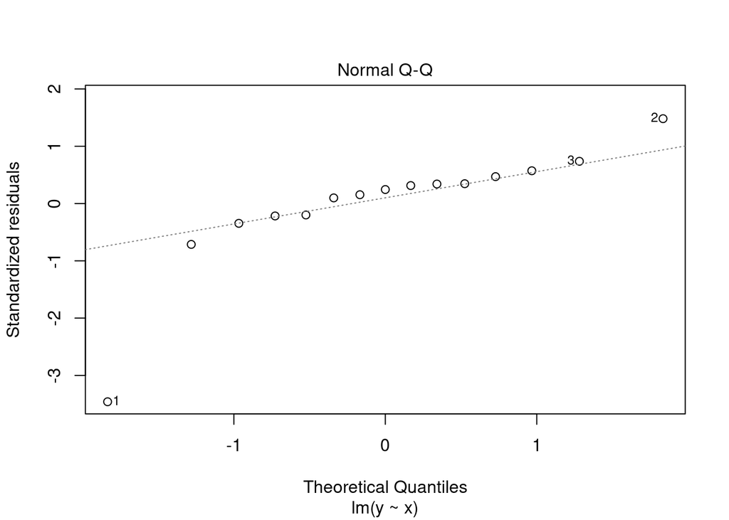

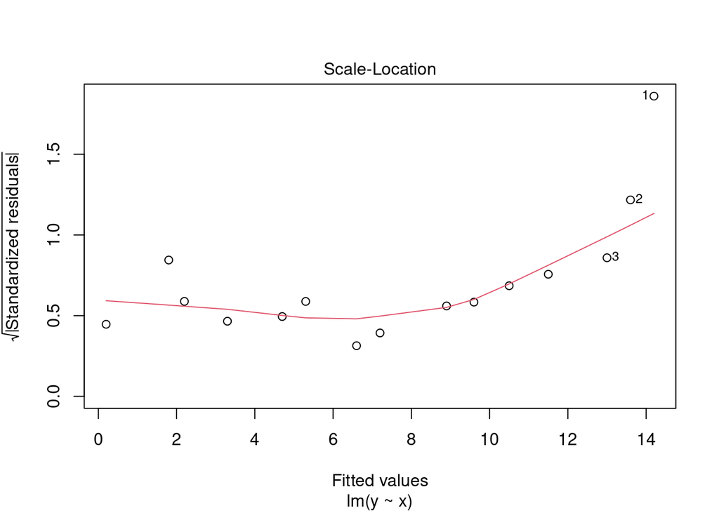

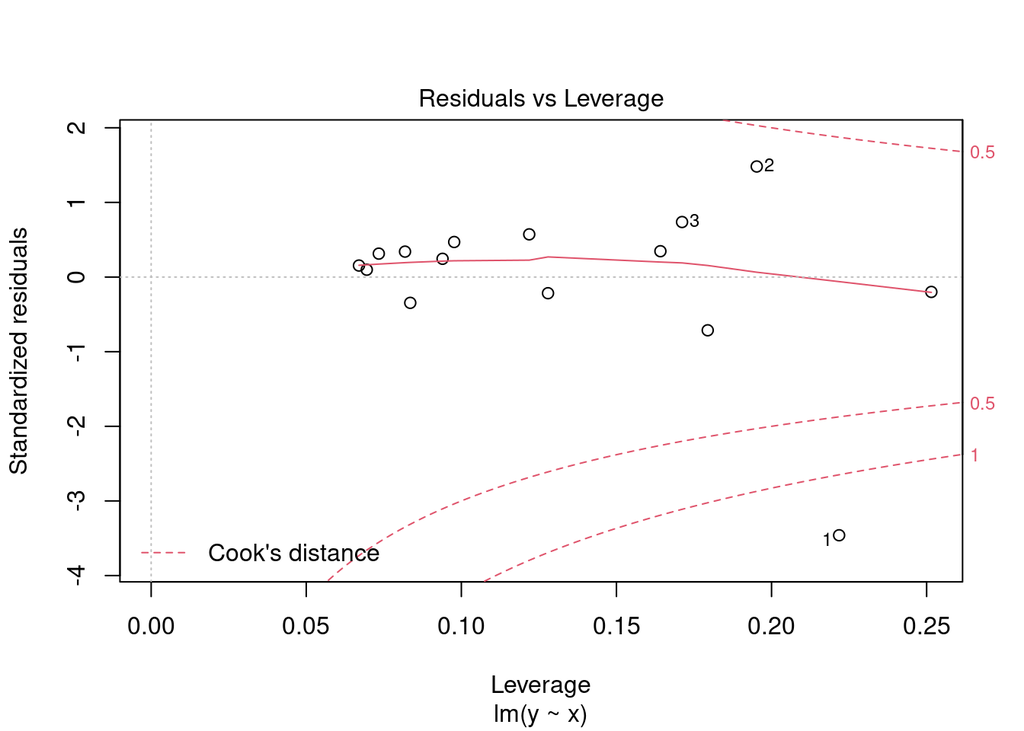

```r
plot(fit)
```

I don’t really know what many of these plots are. Normall Q-Q is looking at the normality of the points in the input. The rest I have no idea about. Maybe a project if someone is interested…

2. In some cases, the best-fitting multiple regression equation is of the form $\hat y=b_0+b_1x+b_2x^2+b_3x^3$. The graph of such an equation is called a cubic. Using the data set given below, and letting $x_1=x$, $x_2=x^2$, and $x_3=x^3$, find the multiple regression equation for the cubic that best fits the given data.

```r
xnew <- c(-8,-7,-2,0,3,6,10)
ynew <- c(3.9,0.9,1.6,4.4,4.4,-5.2,-45.3)
xsquare = xnew^2
xcube = xnew^3
quadraticfit = lm(ynew~xnew+xsquare+xcube)
summary(quadraticfit)
```

```
##
## Call:
## lm(formula = ynew ~ xnew + xsquare + xcube)
##
## Residuals:
##          1          2          3          4          5          6          7
##  8.218e-02 -1.074e-01 -4.438e-02  1.710e-01 -1.418e-01  4.047e-02 -1.704e-05
##
## Coefficients:
##               Estimate Std. Error t value Pr(>|t|)
## (Intercept)  4.2290494  0.0936073   45.18 2.39e-05 ***
## xnew         1.0595259  0.0296256   35.76 4.81e-05 ***
## xsquare     -0.1972106  0.0021918  -89.98 3.03e-06 ***
## xcube       -0.0404032  0.0004339  -93.12 2.73e-06 ***
## ---
## Signif. codes:  0 '***' 0.001 '**' 0.01 '*' 0.05 '.' 0.1 ' ' 1
##
## Residual standard error: 0.1541 on 3 degrees of freedom
## Multiple R-squared:      1,  Adjusted R-squared:  0.9999
## F-statistic: 2.749e+04 on 3 and 3 DF,  p-value: 3.724e-07
```

I’ll conclude with a graphic!

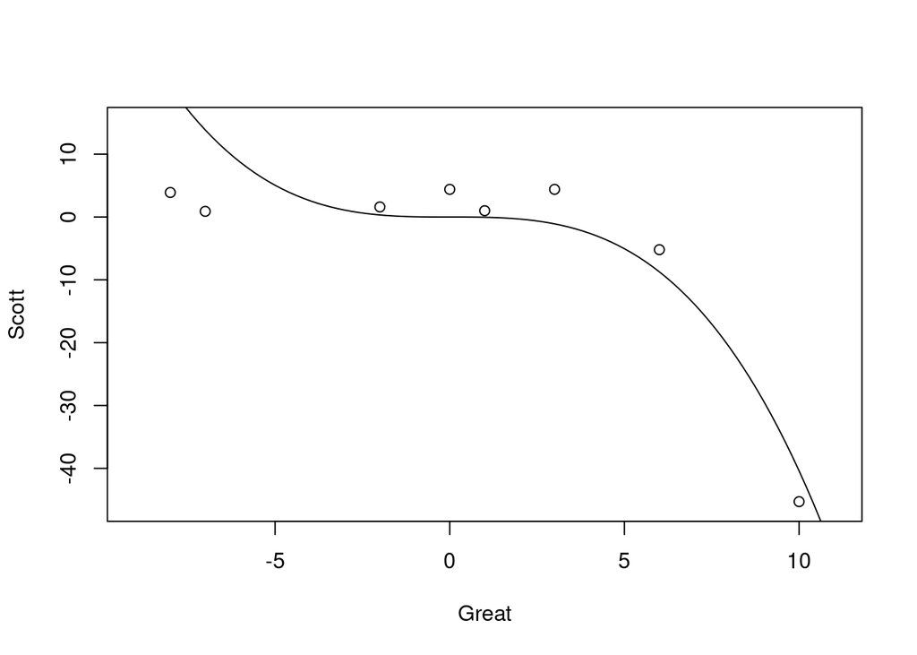

```r
eqn = function(x){
  coef(quadraticfit)[1]
  +
    coef(quadraticfit)[2]*x
  +
    coef(quadraticfit)[3]*x^2
  +
    coef(quadraticfit)[4]*x^3}
plot(x=1, xlim = c(-9,11),ylim = c(-46,15), xlab = "Great",ylab = "Scott")
points(xnew,ynew)
curve(eqn, add = TRUE)
```

This was harder than I thought it would be, I do prefer the ggplot2 package!